# An Introduction to Package ‘MR.Rerand’

## Introduction

`MR.Rerand` is a package that can implement (i)Re-randomized Inverse Variance Weighting (RIVW) estimator in two-sample MR to first conduct re-randomization and Rao-Blackwellization, then estimate the causal effect from the exposure variable $X$ to the outcome variable $Y$. This method can eliminate the measurement error and the winner’s curse bias simultaneously. (ii) Mediation Analysis framework through GWAS summary data Integration with the winner’s (and the loser’s) curse and measurement bias Correction (MAGIC). This method can estimate the parameters $\tau_X$, $\tau_Y$, $\theta$ in the below causal diagram and the mediation effect $\tau=\tau_X\tau_Y$, the total effect $\theta+\tau$, not only correcting the winner’s (and the loser’s) curse and measurement bias, but also improve the efficiency.

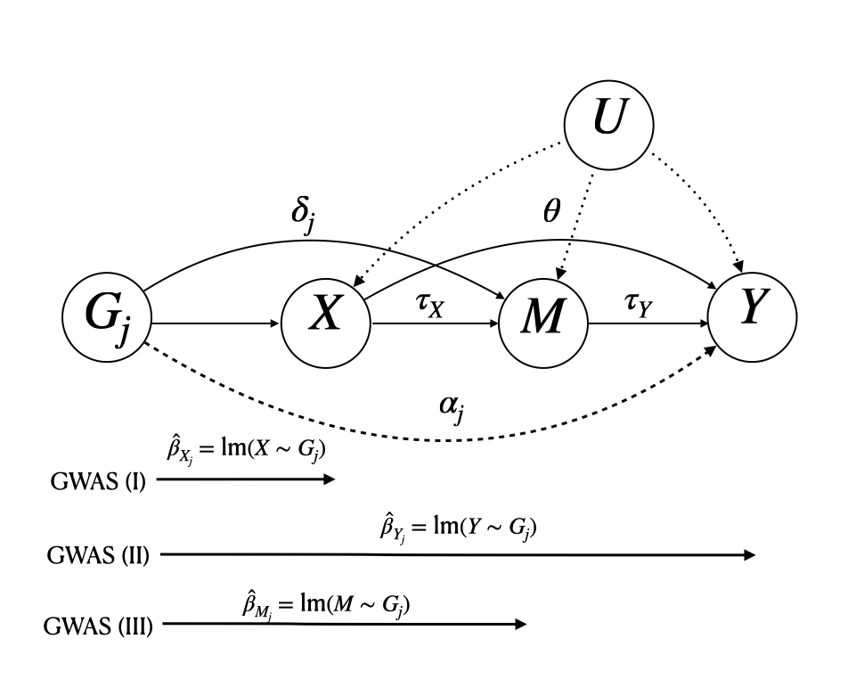

```r
knitr::include_graphics("D:\\Research\\Rpackages\\MR.Rerand\\man\\figures\\causal_diagram.jpeg")
```

## Installation

```r
devtools::install_github("LQRrrrr/MR.Rerand")
```

## Quick start

First we load the `MR.Rerand` package:

```r
library(MR.Rerand)
```

We set $\theta=-0.2, \tau_Y=0.2, \tau_X=0.6$ and generate the three sample GWAS summary statistics.

```r
 M=100000
   pi1=pi2=0.02
   pi3=0.02
   nx=ny=nm=100000
   se_x=rep(sqrt(1/nx),M)
   se_y=rep(sqrt(1/ny),M)
   se_m=rep(sqrt(1/nm),M)
   sigma2x=sigma2y=0.5e-4
   theta=-0.2
   tauY=0.2
   tauX=0.6
  gamma=rep(0,M)
  ind1=sample(M,round(M*pi1))#valid for betaXj
  causalsnps=ind1
  ## simulation 1 (see more simulation settings in reference 2)
  ind3=sample(setdiff(1:M,causalsnps),round(M*pi3))# valid for sj
  causalsnps=c(causalsnps,ind3)
  alpha=rep(0,M)
  gamma[ind1]=rnorm(length(ind1),0,sd=sqrt(sigma2x))
  alpha[ind3]=rnorm(length(ind3),0,sd=sqrt(sigma2y))
  gammam=tauX*gamma+alpha# pleiotropy sj
  gammay=theta*gamma+tauY*gammam#no pleiotropy
      betax=gamma
      betam=gammam
      betay=gammay
      betahat_x=gamma+rnorm(M,mean=0,sd=sqrt(1/nx))
      betahat_m=gammam+rnorm(M,mean=0,sd=sqrt(1/nm))
      betahat_y=gammay+rnorm(M,mean=0,sd=sqrt(1/ny))
```

## Conducting mediation analysis

```r
mediaiton.result=MAGIC(betahat_x,betahat_m,betahat_y,se_x,se_m,se_y)
```

### Result summary

The estimated parameters with corresponding standard errors.

```r
#theta
print(mediaiton.result$theta.hat)
```

```
#> [1] -0.2344205
```

```r
print(mediaiton.result$theta.se)
```

```
#> [1] 0.02451248
```

```r
#tauY
print(mediaiton.result$tauy.hat)
```

```
#> [1] 0.2459457
```

```r
print(mediaiton.result$tauy.se)
```

```
#> [1] 0.02085329
```

```r
#tauX
print(mediaiton.result$taux.hat)
```

```
#> [1] 0.6079544
```

```r
print(mediaiton.result$taux.se)
```

```
#> [1] 0.02916122
```

```r
#tau
print(mediaiton.result$tau.hat)
```

```
#> [1] 0.1495238
```

```r
print(mediaiton.result$tau.se)
```

```
#> [1] 0.01454208
```

```r
#total effect
print(mediaiton.result$tau_total.hat)
```

```
#> [1] -0.08489673
```

```r
print(mediaiton.result$tau_total.se)
```

```
#> [1] 0.02046657
```

The number of IVs selected in the exposure dataset and the mediator dataset and the corresponding indexs.

```r
# number of IVs selected
print(mediaiton.result$n.IV.exp)
```

```
#> [1] 247
```

```r
print(mediaiton.result$n.IV.med)
```

```
#> [1] 253
```

```r
#IVs positions
print(mediaiton.result$IV.exp)
```

```
#>   [1]   616  1265  1294  1313  1968  2055  2131  3230  4686  4982  5241  5512
#>  [13]  5796  6995  7699  7868  7882  8045  8151  8679  8728  8755  9994 10712
#>  [25] 11476 12326 12389 12436 12615 12891 13505 13666 13845 14227 14291 14439
#>  [37] 14708 15013 15043 15153 15433 17090 17332 17853 17953 18501 18586 18691
#>  [49] 18756 19646 19709 19753 19877 19900 19920 19954 20233 21836 22316 22395
#>  [61] 22532 22610 23048 23226 24603 25164 26843 27993 28486 28700 29214 29221
#>  [73] 29674 29967 30012 30118 30726 31173 31364 32048 32454 33475 34646 35034
#>  [85] 35844 36194 36413 36719 38622 40054 40295 40387 41543 41623 41776 41864
#>  [97] 41994 42082 43605 44100 45035 45702 46143 46178 47574 48003 48064 48454
#> [109] 48987 49121 49414 49588 49699 50463 50767 50985 51493 52324 52505 52816
#> [121] 52936 53149 53653 53798 53913 55733 56211 56774 57393 57471 58105 58188
#> [133] 58404 58453 58765 59421 59942 60356 60731 61932 62036 62607 63037 63868
#> [145] 64087 64313 64501 64854 64858 65379 66337 66461 67494 67698 67781 67886
#> [157] 68809 69522 69683 69781 70657 71157 71841 72975 73335 73501 74357 74732
#> [169] 75481 75527 76093 76702 76992 77021 77299 78042 78049 78983 79110 79346
#> [181] 79603 79636 80101 80172 80790 80966 81268 81334 81456 81481 81739 81992
#> [193] 83080 83312 83564 83748 83915 83918 84671 84736 85061 85114 85342 85858
#> [205] 86241 86311 87696 87811 88370 88418 89846 89941 90328 90468 90741 90777
#> [217] 90967 91060 91613 91626 92068 92157 92584 92709 93412 93657 94386 94655
#> [229] 94709 95577 96432 96540 96631 96765 97344 97462 97783 97891 98405 98687
#> [241] 99002 99128 99335 99368 99553 99726 99866
```

```r
print(mediaiton.result$IV.med)
```

```
#>   [1]   145   737  1097  1153  1335  1529  2423  3117  3217  3346  3531  3545
#>  [13]  3915  4294  4709  5424  6255  6299  6566  6626  6693  7156  7595  7596
#>  [25]  8233  8416  8711 10124 10129 10460 10939 11015 11306 11410 11494 11648
#>  [37] 11704 11745 12728 13297 13417 15433 16746 17137 17332 17634 17947 18134
#>  [49] 18231 18437 18495 18586 18734 18736 18874 19040 19900 20073 20190 20495
#>  [61] 20783 21235 21605 21898 21930 22360 22424 22433 22840 23048 23143 23292
#>  [73] 23348 23390 23567 23881 25668 27563 27764 27967 28075 28085 28312 28844
#>  [85] 29451 30340 30450 30551 31814 32056 32196 32266 32395 33203 34186 34749
#>  [97] 35628 35663 36524 36533 36960 37015 37520 37856 37872 38117 38933 39248
#> [109] 40169 40530 41123 41441 42537 42829 43546 44100 44210 44694 44718 44768
#> [121] 45626 45856 45947 46699 47138 47154 47158 48003 48267 49285 49311 49699
#> [133] 49704 49721 50174 50547 52172 52322 52481 52543 52958 53031 53759 54265
#> [145] 54412 54859 55536 56931 57497 57575 57804 57829 58523 58765 58829 59801
#> [157] 60355 60477 61611 61932 62036 62607 62828 62950 63028 63048 63053 63237
#> [169] 63712 64190 64391 65312 65379 65891 66754 67315 68729 68783 68809 68989
#> [181] 69683 70332 70412 71322 71575 71738 71973 72381 72718 72836 72975 73188
#> [193] 73461 73503 74162 74269 74495 74724 75592 76688 76848 77922 77974 78231
#> [205] 78909 79161 79425 80429 80723 80888 81040 81632 82159 82420 82758 83144
#> [217] 83182 83848 84192 84702 85114 85912 85926 86074 87217 88169 88182 88752
#> [229] 89253 89570 90254 92070 92101 92528 92547 93064 93660 93845 94270 95030
#> [241] 95508 96335 96440 96733 97344 97361 97859 97932 98325 99002 99028 99306
#> [253] 99658
```

Confidence Intervals for each estimator

```r
mediaiton.result$Conf.Interval
```

```
#>           Lower Bound Upper Bound
#> theta      -0.2824641 -0.18637695
#> tauy        0.2050740  0.28681744
#> taux        0.5507995  0.66510936
#> tau         0.1210219  0.17802574
#> tau.total  -0.1250105 -0.04478299
```

## Conduct RIVW to estimate the causal effect $\tau_X$ from $X$ to $M$ with smoothing

RIVW smoothing estimator uses all the SNPs to estimate the causal effect.

```r
 RIVW.result.smoothing=RIVW(betahat_x,betahat_m,se_x,se_m,smoothing = TRUE)
```

### Result Summary

The estimated causal effect and the standard error.

```r
print(RIVW.result.smoothing$beta.hat)
```

```
#> [1] 0.5849097
```

```r
print(RIVW.result.smoothing$beta.se)
```

```
#> [1] 0.02318988
```

## Conduct RIVW to estimate the causal effect $\tau_X$ from $X$ to $M$ without smoothing

```r
 RIVW.result=RIVW(betahat_x,betahat_m,se_x,se_m)
```

### Result Summary

The effect sizes and the standard errors after Rerandomization and Rao-Blackwellization.

```r
print(RIVW.result$beta.rerand)
```

```
#>   [1] -3.097815e-03 -1.081848e-02 -1.976656e-02  1.471889e-02 -1.167623e-02
#>   [6]  8.244473e-03  1.003242e-02 -1.098124e-02  1.714373e-02  7.894998e-03
#>  [11] -6.308451e-03  5.948461e-04 -1.691980e-02 -1.611637e-02  8.591778e-03
#>  [16]  7.350681e-03 -8.705818e-05 -1.684555e-02  3.436750e-03  4.418633e-03
#>  [21] -2.958038e-03  1.515041e-02 -7.145639e-03 -2.036821e-02  8.236497e-03
#>  [26] -8.912691e-03  2.053394e-02  4.715381e-03  1.859518e-02  1.303629e-02
#>  [31]  6.453309e-03  1.676336e-02  1.453512e-04 -1.692463e-02  1.291357e-02
#>  [36]  1.648865e-02  2.200904e-03 -1.829264e-02 -2.642925e-03 -1.481107e-02
#>  [41]  9.428107e-03 -5.142616e-03 -1.759937e-02 -1.253835e-02 -1.176879e-02
#>  [46]  8.714249e-03 -1.350713e-02  1.510608e-02 -1.267501e-02  1.774564e-02
#>  [51] -8.013555e-03 -1.549834e-02  1.219040e-02  2.008200e-02 -1.275877e-02
#>  [56] -5.944839e-03 -2.565472e-02 -1.638387e-02 -1.406547e-02  1.970602e-02
#>  [61]  1.444640e-02 -1.437714e-02 -2.009535e-02  1.026710e-02  1.131413e-02
#>  [66] -1.324335e-02  1.387413e-02 -1.053434e-02 -1.792559e-02  1.810728e-02
#>  [71]  2.328152e-02 -7.307207e-03 -1.285898e-02 -1.280586e-02 -4.400851e-03
```

[output cut: 35 more lines]

```r
print(RIVW.result$se.rerand)
```

```
#>   [1] 0.006393717 0.005438273 0.003163000 0.004205454 0.005235081 0.005892089
#>   [7] 0.006831939 0.005402114 0.003311771 0.006795173 0.006126717 0.006587713
#>  [13] 0.003362436 0.003620087 0.005841790 0.006009270 0.006558250 0.003381422
#>  [19] 0.006370840 0.006298280 0.006402853 0.004021682 0.006033891 0.003162415
#>  [25] 0.005893211 0.005792679 0.003162362 0.006274331 0.003173987 0.004839616
#>  [31] 0.006765744 0.003403694 0.006555618 0.003361238 0.004879461 0.003487282
#>  [37] 0.006449516 0.003184025 0.006663309 0.004166594 0.005708051 0.006238032
#>  [43] 0.003238001 0.004995944 0.005211185 0.005823356 0.004678515 0.004040721
#>  [49] 0.004954436 0.003221697 0.005923990 0.003872479 0.005097047 0.003162586
#>  [55] 0.004928480 0.006163511 0.003162278 0.003522600 0.004470423 0.003163124
#>  [61] 0.004318422 0.004346609 0.003162575 0.005553217 0.005324749 0.004770393
#>  [67] 0.004543788 0.005498917 0.003205692 0.003193371 0.006956376 0.006014556
#>  [73] 0.004896902 0.004913711 0.006299683 0.003414872 0.006679011 0.006004416
#>  [79] 0.005899196 0.006499488 0.006556646 0.005835746 0.006102774 0.003185600
#>  [85] 0.005508641 0.006766151 0.005996452 0.006149667 0.004957014 0.003162278
```

[output cut: 26 more lines]

The estimated causal effect, the standard error, and the p-value.

```r
print(RIVW.result$beta.hat)
```

```
#> [1] 0.5770769
```

```r
print(RIVW.result$beta.se)
```

```
#> [1] 0.02557797
```

```r
print(RIVW.result$p.val)
```

```
#> [1] 1.035968e-112
```

The position of selected IVs and the number of IVs.

```r
print(RIVW.result$IV)
```

```
#>   [1]    81   616  1265  1294  1313  1380  1418  2055  2131  2748  3230  3857
#>  [13]  4982  5241  6889  7699  7858  7882  8540  8571  8691  9994 11077 11476
#>  [25] 12262 12389 12436 12615 13666 13845 14075 14227 14583 14708 15043 15433
#>  [37] 17002 17090 17247 17332 17642 18495 18501 18586 18756 19383 19709 19753
#>  [49] 19877 19900 19920 20233 20968 21836 22316 22532 23048 23226 24603 25164
#>  [61] 26843 27804 27993 29214 29221 29967 30012 31173 31364 33475 34190 34321
#>  [73] 35034 35437 35546 35844 36193 36288 36413 37379 38604 38622 38744 40295
#>  [85] 40387 40433 40967 41377 41623 41776 41994 42584 43032 43185 43401 44100
#>  [97] 45035 45702 46178 47507 47574 48003 48064 48462 48987 49121 49588 49699
#> [109] 50463 51296 51493 51537 52324 52505 52694 52816 52936 53149 53653 53913
#> [121] 53945 54413 54425 55733 55951 56064 56930 57016 57189 58105 58404 58765
#> [133] 59148 59421 59942 60555 60731 61932 62036 63847 63868 64087 64313 64501
#> [145] 64522 64854 64858 65379 65629 66461 67781 67886 68809 68931 69683 69781
#> [157] 70374 70657 71469 71738 71841 72975 73335 73461 73501 75481 75527 76992
#> [169] 77021 77299 77659 78042 78049 78688 79110 79346 79603 79624 80101 80172
#> [181] 80534 80790 80966 81268 81334 81456 81481 81739 81992 82185 83240 83312
#> [193] 83564 83748 84027 84736 85061 85114 85858 86204 86241 87217 88005 88418
#> [205] 89098 89443 89846 89941 90328 90741 90777 91060 91626 92157 92330 92528
#> [217] 92584 92709 93412 93681 94386 94655 94709 95461 95577 96311 96334 96432
#> [229] 96443 96523 96540 96631 96635 96765 96848 97344 97462 97783 97891 98030
#> [241] 98405 99002 99128 99131 99335 99866
```

```r
print(RIVW.result$n.IV)
```

```
#> [1] 246
```

The F-statistics of selected IVs

```r
RIVW.result$F
```

```
#> [1] 22.03946
```

The confidence interval

```r
RIVW.result$Conf.Interval
```

```
#> [1] 0.5269450 0.6272088
```